# Homework

## Statistics warm-up

Consider a random variable $X$ with a probability density function

$$f(x) = \frac{c}{\sqrt{x(b-x)}}, \quad 0<x<b,$$
where $c$ is a normalising constant and $b$ is a parameter.

- Find $c$ such that the probability density function is valid.

A PDF is valid if integrating it over its bounds results in 1, or when $\int_0^b\frac{c}{\sqrt{x(b-x)}}dx=1$. Thus, we solve for c as follows, using trig substitution:
$$c=\frac{1}{\int_0^b\frac{1}{\sqrt{x(b-x)}}dx}$$
$x=bsin^2\theta$ and thus $dx=2b\sin\theta \cos\theta$, since it is a standard trig substitution. Adjusting the bounds of the integral, we have $0=b\sin^2\theta \rightarrow\theta=0$ and $b=b\sin^2\theta\rightarrow\theta=\frac{\pi}{2}$. Plugging in our substitution, we get:
$$c=\frac{1}{2\int_0^{\frac{\pi}{2}}\frac{b\sin\theta\cos\theta}{\sqrt{b\sin^2\theta(b-b\sin^2\theta)}}
d\theta}=\frac{1}{2\int_0^{\frac{\pi}{2}}\frac{b\sin\theta\cos\theta}{\sqrt{b^2
\sin^2\theta(cos^2\theta)}} d\theta}$$
Hence,
$$c=\frac{1}{2\int_0^\frac{\pi}{2}\frac{b\sin\theta\cos\theta}{b\sin\theta\cos\theta}d\theta}=\frac{1}{2\frac{\pi}{2}}=\boxed{\frac{1}{\pi}}$$
Thus, the PDF is valid when c is $\frac{1}{\pi}$.

- Find the corresponding cumulative distribution function, $F(x)$ and its inverse $F^{-1}(x)$. To find the CDF, integrate from 0 to x the PDF using a dummy variable, for instance, t.
  $$F(x)=\int_0^x\frac{1}{\pi\sqrt{t(b-t})}dt$$
  From the previous part, we know that $\frac{dt}{\sqrt{t(b-t)}}=2d\theta$ when using the substitution $t=b\sin^2\theta$. Adjusting the bounds, we have $0=b\sin^2\theta \rightarrow\theta=0$ and $x=b\sin^2\theta \rightarrow \theta=\arcsin(\sqrt{\frac{x}{b}})$. Compiling this, we get:

$$\boxed{F(x)=\frac{2\arcsin(\sqrt{\frac{x}{b}})}{\pi};
\ 0<x<b}$$
with $F(x)=0$ for $x\leq 0$ and $F(x)=1$ for $x\geq b$.

We can solve for the inverse by simply rearranging the equation and replacing the variables. To find the domain, we use the fact that for the square root in $F(x)$ to be valid, $\frac{x}{b}\geq0$, meaning $0\leq \arcsin (\sqrt{\frac{x}{b}})\leq \frac{\pi}{2}$, and therefore $0\leq F(x)\leq1$. Since the domain of an inverse function is the original function’s range, the inverse is valid for $0<x<1$.

$$\boxed{F^{-1}(x)=b\sin^2(\frac{\pi
x}{2}); \ 0<x<1}$$

- Describe a procedure to generate samples distributed according to $X$, given a set of uniformly distributed samples $u_1,\dots,u_n \sim \mathcal{U}[0,1]$.

Using the Universality of the Uniform, plugging in a $U(0,1)$ random variable into an inverse CDF causes it to be distributed according to the original function. In other words, $F^{-1}(U)$ is distributed the same as $X$, since $F^{-1}$ is the inverse CDF of $X$. Thus, we can generate as many samples as needed by finding $F^{-1}(U_1), F^{-1}(U_2),...$.

- Set the seed to 42 and generate 1,000 samples distributed according to $X$ using 1,000 uniformly distributed i.i.d. $\mathcal{U}[0,1]$ samples, with $b=5$. Plot a histogram of the resulting samples.

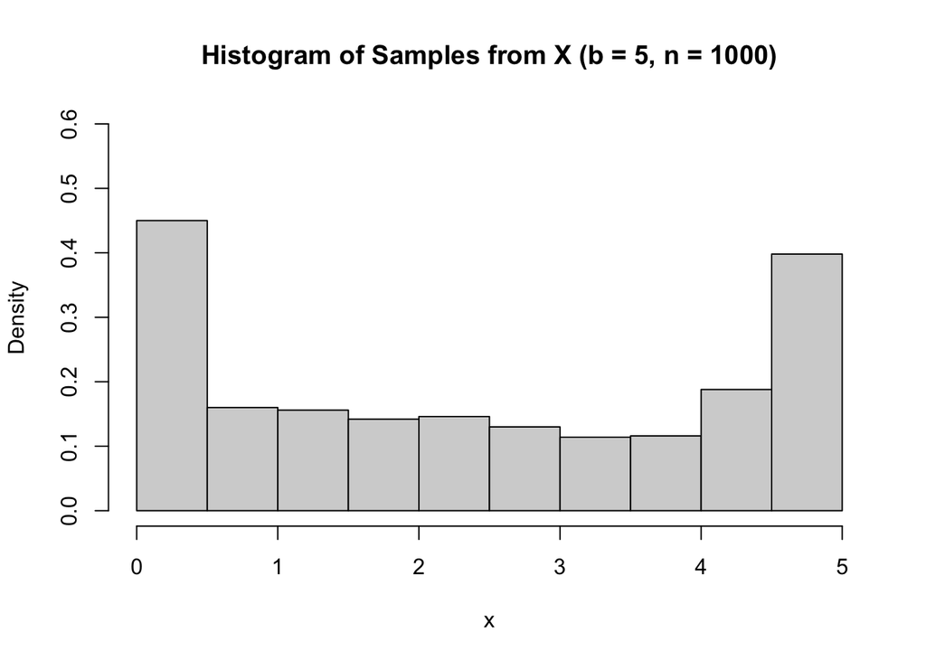

```r
set.seed(42)

n <- 1000
b <- 5

#Define u and F_inv

u <- runif(n)

F_inv <- function(u, b) {
  b * (sin(pi * u / 2))^2
}

x <- F_inv(u, b)

#Plot histogram
hist(
  x,
  probability = TRUE,
  main = "Histogram of Samples from X (b = 5, n = 1000)",
  xlab = "x",
  ylim = c(0,0.6)
)
```

- Assume that we have a set of samples $X_1,\dots,X_n$ which are i.i.d. as $X$ with $b$ unknown. Find the log-likelihood function for the parameter $b$, $\ell(b;x_1,\dots,x_n)$ and find its derivative with respect to $b$, $\frac{d\ell}{db}$.

Let $\ell(b;\mathbf{x}) = \log L(b;\mathbf{x})=\sum\limits^n_{j=1}\log f(x_j; b)$, where $f$ is the PDF of $X$ as given in the first part. Hence,
$$\ell = \sum\limits^n_{j=1}\log
(\frac{1}{\pi \sqrt{x_j(b-x_j)}})=\sum\limits^n_{j=1}[-\log
(\pi)-\frac{1}{2}\log(x_j)-\frac{1}{2}\log (b-x_j)]$$
We can drop any additive constants since they would become 0 when finding the derivative w.r.t. $b$, so
$$\dfrac{d\ell}{db}=\dfrac{d}{db}[-\frac{1}{2}\sum\limits^n_{j=1}\log(b-x_j)]=-\frac{1}{2}\sum\limits^n_{j=1}\frac{1}{b-x_j}$$

- Based on the likelihood, or otherwise, give a statistic based on $X_1,\dots,X_n$ which is a reasonable estimator for the unknown parameter $b$. Explain your choice.

We can use MLE (maximum likelihood estimation) to estimate $b$. In this case, we want to maximize the likelihood, so we check for cases where $\dfrac{d\ell}{db}=0$, as well as at the endpoints. In this case, we cannot solve for $-\frac{1}{2} \sum\limits^n_{j=1}\frac{1}{b-x_j} = 0$, so the maximum likelihood must be at either one of the endpoints. Since it is given that the support of X is $0<x<b$, $b>X_{(n)},$ which is the order statistic for the maximum value of X in the sample. Hence, we know that the domain of the likelihood function is $(X_{(n)},\infty)$, meaning $\frac{1}{b-x_j}$ is always positive and thus the derivative of the likelihood function is always negative. Thus, we know that we can reasonably estimate $b$ to be the value that is closest to $X_{(n)}$ as possible, as this is the smallest value that $b$ can possibly be. In other words, $\hat{b} = X_{max}$.

- The file `samples.rds` contains samples $X_1,\dots,X_n$ distributed according to $X$. Report the estimated value of $\hat{b}$ based on those samples.

```r
x <- readRDS("hw_files/data/samples.rds")
summary(x)
```

```
##      Min.   1st Qu.    Median      Mean   3rd Qu.      Max.
##  0.000012 10.594536 39.970682 41.329166 72.144022 85.199521
```

```r
max(x)
```

```
## [1] 85.19952
```

Hence, $X_{max}=85.19952$, so $\hat{b} =85.19952$.

## Arrays

You are given a multi-dimensional array `array.rds`. It contains penetrance curves for various cancers and genes. In simple terms, penetrances are how likely one will develop a cancer given that they have a certain corresponding gene mutation. Other variables in `data` describe different sub-populations. For example, the probabilities corresponding to `Brain` cancer and gene `APC` are the probabilities for which a person will develop brain cancer, given that they have a mutation in the `APC` gene.

- Read in the data and give the dimensions of the array.

*Hint: Use the `str` function.*

```r
x <- readRDS("hw_files/data/array.rds")
str(x)
```

```
##  num [1:18, 1:26, 1:8, 1:2, 1:94] 3.98e-05 2.80e-07 0.00 5.00e-08 0.00 ...
##  - attr(*, "dimnames")=List of 5
##   ..$ Cancer: chr [1:18] "Brain" "Breast" "Cervical" "Colorectal" ...
##   ..$ Gene  : chr [1:26] "APC" "ATM" "BARD1" "BMPR1A" ...
##   ..$ Race  : chr [1:8] "All_Races" "AIAN" "Asian" "Black" ...
##   ..$ Sex   : chr [1:2] "Female" "Male"
##   ..$ Age   : chr [1:94] "1" "2" "3" "4" ...
```

Hence the array has 5 dimensions: cancer, gene, race, sex, and age.

- Subset the array for the penetrances associated with `Breast` cancer and the `BRCA2` gene for a female with the default race `All_Races`. Then plot the penetrance curve (probability versus age).

```r
x["Breast", "BRCA2", "All_Races", "Female", ]
```

```
##            1            2            3            4            5            6
## 0.000000e+00 1.880000e-09 1.320000e-08 4.000000e-08 7.000000e-08 1.150000e-07
##            7            8            9           10           11           12
## 1.710000e-07 2.390000e-07 3.180000e-07 7.630000e-07 1.440000e-06 1.950000e-06
##           13           14           15           16           17           18
## 2.270000e-06 2.410000e-06 2.380000e-06 2.160000e-06 1.770000e-06 4.150000e-06
##           19           20           21           22           23           24
## 7.380000e-06 1.060000e-05 3.750000e-05 1.018000e-04 1.982420e-04 3.268320e-04
##           25           26           27           28           29           30
## 4.875690e-04 6.804530e-04 9.054840e-04 1.162663e-03 1.451990e-03 3.088216e-03
##           31           32           33           34           35           36
## 5.833457e-03 8.254016e-03 1.034989e-02 1.212109e-02 1.356760e-02 1.468944e-02
##           37           38           39           40           41           42
## 1.548659e-02 1.595906e-02 1.610685e-02 1.633931e-02 1.682062e-02 1.722351e-02
##           43           44           45           46           47           48
## 1.754797e-02 1.779401e-02 1.796163e-02 1.805083e-02 1.806160e-02 1.799395e-02
##           49           50           51           52           53           54
## 1.784788e-02 1.763550e-02 1.740522e-02 1.716917e-02 1.692733e-02 1.667971e-02
##           55           56           57           58           59           60
## 1.642630e-02 1.616712e-02 1.590215e-02 1.563140e-02 1.535487e-02 1.507245e-02
##           61           62           63           64           65           66
## 1.478375e-02 1.448866e-02 1.418717e-02 1.387930e-02 1.356504e-02 1.324439e-02
##           67           68           69           70           71           72
## 1.291735e-02 1.258392e-02 1.224410e-02 1.190312e-02 1.158189e-02 1.128563e-02
##           73           74           75           76           77           78
## 1.101435e-02 1.076806e-02 1.054673e-02 1.035039e-02 1.017903e-02 1.003264e-02
##           79           80           81           82           83           84
## 9.911229e-03 9.806565e-03 9.685724e-03 9.540474e-03 9.370815e-03 9.176747e-03
##           85           86           87           88           89           90
## 8.958270e-03 8.715384e-03 8.448089e-03 8.156386e-03 7.840273e-03 7.501516e-03
##           91           92           93           94
## 7.147168e-03 6.778995e-03 6.396996e-03 6.001170e-03
```

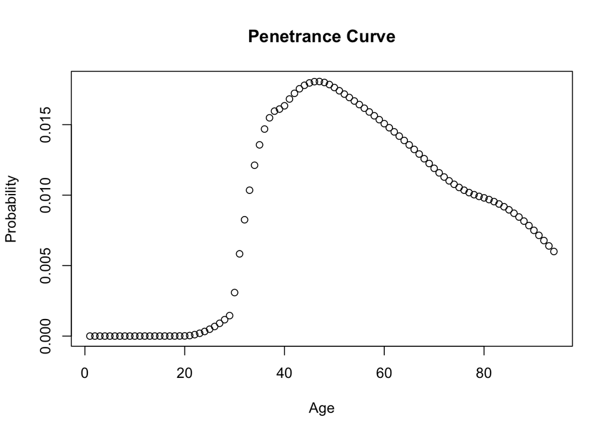

```r
prob <- x["Breast", "BRCA2", "All_Races", "Female", ]
age <- seq_along(prob)
plot(age, prob,
  xlab = 'Age',
  ylab = 'Probability',
  main = 'Penetrance Curve')
```

- Subset the array for the penetrances associated with `Colorectal` cancer and the `PALB2` gene for an Asian male. What is the probability that a person from this subpopulation at age 50 will develop colorectal cancer in the next 10 years given that he has tested positive for a PALB2 mutation but is otherwise disease free?

```r
sum(x["Colorectal", "PALB2", "Asian", "Male", 1:94])
```

```
## [1] 0.06808534
```

## Family pedigrees

Read in the `.rdata` file `pedigree.rda`. Each `data.frame` represents a family. Each individual is uniquely identified by the first column called `ID`. Their sex is coded as `0` for females and `1` for males. Individuals’ mother and father are indicated in the `MotherID` and `FatherID` columns. A value of `NA` in these columns means that this person is a so-called ‘founder’ or that a certain parent is missing.

Each pedigree can be thought of as a family tree. For example, a visualisation of a sample pedigree is shown below. The colours indicate affliction status for cancers as labelled in the legend.

[figure not shown]

In the following exercises, you are encouraged to modularise and comment on your code.

- Write an R function(s) to count the number of unique nuclear families there are in a certain pedigree. A nuclear family is defined as the set of two parents and all of their children.

```r
load("hw_files/data/pedigree.rda")
ls()
```

```
##  [1] "age"    "b"      "F_inv"  "fam10"  "fam100" "fam50"  "fam75"  "n"
##  [9] "prob"   "u"      "x"
```

```r
str(fam10)
```

```
## 'data.frame':    10 obs. of  16 variables:
##  $ ID       : int  1 2 3 4 5 6 7 8 9 10
##  $ Sex      : num  0 1 0 1 0 1 0 1 0 1
##  $ MotherID : num  NA NA NA NA 1 1 3 3 7 5
##  $ FatherID : num  NA NA NA NA 2 2 4 4 6 8
##  $ isProband: num  0 0 0 0 0 0 1 0 0 0
##  $ CurAge   : num  92 93 NA 87 55 59 60 62 32 33
##  $ isDead   : num  1 0 0 1 0 0 0 0 0 0
##  $ Twins    : num  0 0 0 0 0 0 0 0 0 0
##  $ riskmod  :List of 10
##   ..$ : chr
##   ..$ : chr
##   ..$ : chr
##   ..$ : chr
##   ..$ : chr
##   ..$ : chr
##   ..$ : chr
##   ..$ : chr "Oophorectomy"
##   ..$ : chr
##   ..$ : chr
##  $ interAge : num  NA NA NA NA NA NA NA 40 NA NA
##  $ race     : chr  "Black" "Asian" "White" "WNH" ...
##  $ Ancestry : chr  "nonAJ" "nonAJ" "nonAJ" "nonAJ" ...
##  $ isAffPANC: num  0 1 0 0 0 0 0 0 0 0
##  $ AgePANC  : num  NA 50 NA NA NA NA NA NA NA NA
##  $ isAffBC  : num  0 0 0 0 0 0 0 1 0 0
##  $ AgeBC    : num  NA NA NA NA NA NA NA 35 NA NA
```

I want to do is go to the first individual and record their MotherID and FatherID. Then I want to create a vector containing these values. I will then loop for each individual available in the pedigree. I will then delete all duplicate vectors and remove any containing NA. This will tell me how many nuclear families there are, since what matters in counting them is the mother-father combination, not the children.

```r
count_nuclear_families <- function(fam_data_frame) {
  pairs <- list() #create vector to store IDs in
  k <- 0          #start at 0 families

  #create for loop that goes individual by individual and records   their MotherID and FatherID
  for (i in seq_len(nrow(fam_data_frame))) {
    mom <- fam_data_frame[i, "MotherID"] #take MotherID number from ith individual
    dad <- fam_data_frame[i, "FatherID"] #take FatherID number from ith individual

    # skip founders (entries with NA)
    if (is.na(mom) || is.na(dad)) next

    #increase counter by 1
    k <- k + 1
    pairs[[k]] <- c(mom, dad) #store mother-father pair in a vector
  }

  # turn list of length-2 vectors into a 2-column matrix
  pair_mat <- do.call(rbind, pairs)

  # count unique (MotherID, FatherID) rows and delete redundancy
  n_unique <- nrow(unique(pair_mat))
  return(n_unique)
}
```

- Report the number of nuclear families for the pedigrees contained in the `.rda` file.

```r
count_nuclear_families(fam10)
```

[output not shown]

```r
count_nuclear_families(fam50)
```

```
## [1] 10
```

```r
count_nuclear_families(fam75)
```

```
## [1] 18
```

```r
count_nuclear_families(fam100)
```

```
## [1] 26
```